# Homework 10

Neeraj Vardhan Buneeti

2024-11-27

## Question 2

# (a)

```r
data <- read.csv("C:/Users/NEERAJ BUNEETI/Desktop/REG/R/LogisticData.csv")
data$Education <- factor(data$Education)
levels(data$Education)
```

```
## [1] "College"    "Graduate"   "HighSchool"
```

```r
data$Education <- relevel(data$Education, ref = "HighSchool")
levels(data$Education)
```

```
## [1] "HighSchool" "College"    "Graduate"
```

# (b)

```r
model <- glm(Purchase ~ Age + Income + Education, data = data, family = binomial)
summary(model)
```

```
##
## Call:
## glm(formula = Purchase ~ Age + Income + Education, family = binomial,
##     data = data)
##
## Coefficients:
##                     Estimate Std. Error z value Pr(>|z|)
## (Intercept)       -2.623e+00  1.025e+00  -2.559 0.010497 *
## Age                6.727e-02  1.953e-02   3.444 0.000572 ***
## Income             2.744e-05  1.100e-05   2.495 0.012604 *
## EducationCollege   2.579e-01  5.497e-01   0.469 0.638936
## EducationGraduate  1.264e+00  6.540e-01   1.933 0.053281 .
## ---
## Signif. codes:  0 '***' 0.001 '**' 0.01 '*' 0.05 '.' 0.1 ' ' 1
##
## (Dispersion parameter for binomial family taken to be 1)
##
##     Null deviance: 146.77  on 199  degrees of freedom
## Residual deviance: 119.81  on 195  degrees of freedom
## AIC: 129.81
##
## Number of Fisher Scoring iterations: 6
```

# (c)

1. The coefficient of Age indicates the magnitude of change in the log-odds of purchasing for every year a person ages.

Log-odds: Log-odds are the logarithm of the probability ratio for an event to occur (in this case, purchasing). Odds are the ratio of probabilities of an event happening versus not happening. Log-odds convert odds into a scale ranging from 0 to +∞.

A positive coefficient for Age suggests that as a person ages, their log-odds of purchasing increase, holding other factors like income and education constant.

Note: The change in log-odds may not be linear; it could be non-monotonic.

2. The coefficient for Income tells us how a one-dollar increase in an individual’s income affects the log-odds of purchasing.

A positive coefficient for Income indicates that as income increases, the likelihood of purchasing also increases. In other words, as income rises, the probability of making a purchase increases.

A negative sign for Income suggests that as income increases, the log-odds of purchasing decrease. This means that having a higher income reduces the likelihood of purchasing, which is uncommon in typical cases (where income correlates with increased spending power).

3. Education is a categorical variable with three levels: “Highschool,” “College,” and “Graduate.” In the model, one of these categories is treated as a reference group (in this case, Highschool). The other groups (College and Graduate) are compared to the reference group.

The coefficients for Education indicate the difference in log-odds of buying between individuals with College and Graduate education levels compared to those with only a high school education (the reference group).

- *Education College:* This variable is coded “1” for individuals with a college education or higher and “O” for those with only a high school education. If the coefficient for Education College is positive, it means that people with a college education are more likely to make a purchase compared to those with only a high school education, holding age and income constant. Conversely, a negative coefficient for Education Graduate suggests that individuals with a graduate degree are less likely to purchase compared to those with only a high school education, all other things being equal.
- *Age:* A higher value indicates a higher likelihood of purchasing for older individuals, while a lower value suggests the opposite.
- *Income:* The sign of the coefficient indicates whether a higher income increases (positive) or decreases (negative) the probability of purchase.
- *Education:* The coefficients compare the likelihood of purchasing among individuals with a college or graduate degree compared to those with only a high school diploma.

# (d)

[output not shown]

# (e)

```r
library(caret)
predictions <- ifelse(predict(model, type = "response") > 0.5, 1, 0)
conf_matrix <- confusionMatrix(as.factor(predictions), as.factor(data$Purchase))
conf_matrix
```

```
## Confusion Matrix and Statistics
##
##           Reference
## Prediction   0   1
##          0   3   1
##          1  21 175
##
##                Accuracy : 0.89
##                  95% CI : (0.8382, 0.9298)
##     No Information Rate : 0.88
##     P-Value [Acc > NIR] : 0.3816
##
##                   Kappa : 0.1864
##
##  Mcnemar's Test P-Value : 5.104e-05
##
##             Sensitivity : 0.1250
##             Specificity : 0.9943
##          Pos Pred Value : 0.7500
##          Neg Pred Value : 0.8929
##              Prevalence : 0.1200
##          Detection Rate : 0.0150
##    Detection Prevalence : 0.0200
##       Balanced Accuracy : 0.5597
##
##        'Positive' Class : 0
##
```

## Question 3

```r
data <- read.csv("C:/Users/NEERAJ BUNEETI/Desktop/REG/R/PoissonData.csv")
head(data)
```

```
##   ER_Visits Age Income Insurance
## 1         1  36     39         0
## 2         4  67     97         1
## 3         4  43     68         0
## 4         0  73     61         1
## 5         0  76     52         1
## 6         9  21     90         1
```

# (a)

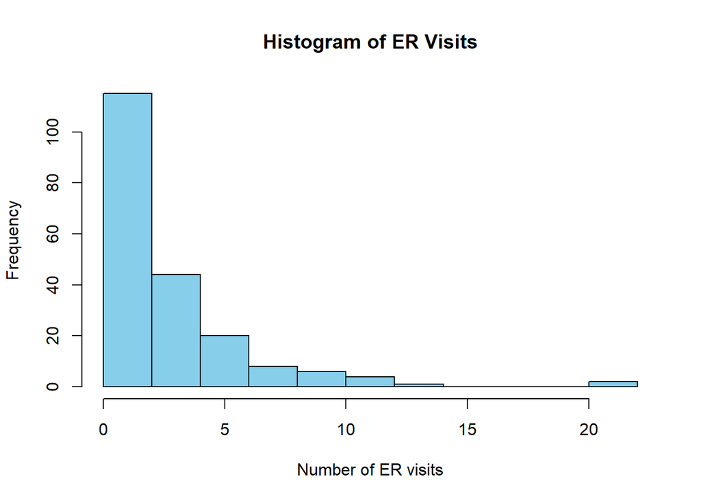

```r
hist(data$ER_Visits, main = "Histogram of ER Visits",
     xlab = "Number of ER visits", col = "Skyblue", border = "black")
```

With this, you’ll obtain a histogram illustrating the distribution of emergency room visits. Given that it’s a count data type, you should anticipate a right-skewed distribution (meaning most individuals rarely visit the ER, while a few people visit frequently, resulting in higher counts). This aligns with the characteristics of count data, and it makes sense that a Poisson distribution could be an appropriate fit.

# (b)

```r
# Fit Poisson regression model
model <- glm(ER_Visits ~ Age + Income + Insurance, family = poisson(link = "log"), data = data)

# View the summary of the model
summary(model)
```

```
##
## Call:
## glm(formula = ER_Visits ~ Age + Income + Insurance, family = poisson(link = "log"),
##     data = data)
##
## Coefficients:
##              Estimate Std. Error z value Pr(>|z|)
## (Intercept)  0.282070   0.193250   1.460    0.144
## Age         -0.022207   0.002758  -8.052 8.12e-16 ***
## Income       0.032216   0.002023  15.921  < 2e-16 ***
## Insurance   -0.601537   0.085762  -7.014 2.32e-12 ***
## ---
## Signif. codes:  0 '***' 0.001 '**' 0.01 '*' 0.05 '.' 0.1 ' ' 1
##
## (Dispersion parameter for poisson family taken to be 1)
##
##     Null deviance: 627.23  on 199  degrees of freedom
## Residual deviance: 214.61  on 196  degrees of freedom
## AIC: 683.35
##
## Number of Fisher Scoring iterations: 5
```

# (c)

These results suggest that the probability of using emergency room services is likely to be lower among individuals with health insurance. This could be due to the fact that insured individuals are better equipped to receive preventative services, routine doctor visits, and other health resources that can help prevent trips to the emergency room. Alternatively, they may be receiving other forms of care that keep them out of the ER.

# (d)

```r
new_data <- data.frame(Age = 40, Income = 50, Insurance = 1)
predicted_visits <- predict(model, newdata = new_data, type = "response")
cat("Predicted number of ER visits:", predicted_visits, "\n")
```

```
## Predicted number of ER visits: 1.496409
```